# Designing and Testing a Relational Database

[Justin Ferguson](https://www.justinferguson.me)

2020-12-17

# Background

The Happy Phone Company is a fictitious retailer of various makes and models of mobile phones. The business requires a new database to help manage data concerning employees, customers, suppliers, phones and contracts.

# Business Rules

*The database must satisfy the following business rules:*

- Information about The Happy Phone Company employees includes an employee ID, name and position.
- Each customer of The Happy Phone Company is identified by a customer ID and has a name.
- Suppliers to The Happy Phone Company have a unique name and contact phone number.
- Phones stocked by The Happy Phone Company are described by a product code, retail price and stock quantity.
- Details of phones need to be kept, including make and model information.
- Contracts supplied by The Happy Phone Company are described by a contract number, contract term in months and contract price.
- A phone must have at least one supplier and each supplier can supply many phones. When a supplier supplies a phone, data includes a supply price, the quantity supplied and the date of the supply. If a supplier provides several supplies of a phone, only data for the most recent supply is kept.
- Details of a purchase by a customer shall include the date of purchase and a contract number (if applicable). A customer can purchase several phones in a single day and the details of each purchase must be kept.

# Functional Dependencies of the Business Rules

The first step in creating a relational database is to obtain the functional dependencies from the business rules. A functional dependency is a logical relationship between two sets of attributes X={X<sub>1</sub>, X<sub>2</sub>, …, X<sub>n</sub>} and Y={Y<sub>1</sub>, Y<sub>2</sub>, …, Y<sub>n</sub>}, and must satisfy the criteria X → Y, where the arrow notation is read in plain english as *determine*. In other words, all attributes together in X determine any attribute in Y, and any attribute in Y must be related to those in X.  
The following are the set of minimal basis functional dependencies drawn from the business rules:

employee ID → employee name, position  
customer ID → customer name  
supplier name → phone number  
product code → make, model, retail price, stock quantity  
purchase number, contract number → contract term, contract price  
supplier name, product code → supply price, supply quantity, supply date  
purchase number → customer ID, product code, employee ID, purchase date

# Normalisation

The process of normalisation in database design removes data redundancy by measuring the goodness of a relational schema with respect to the *normal forms*. An important concept in normalisation is the *key* of a relation. For a functional dependency X → Y, a key is the set of attributes in X that completely determine the remaining attributes in Y of a relation.  
The following points describe the levels of normal forms, where higher normal forms remove data redundancy more deeply.

*First Normal Form (1NF):* Attributes of a relation are atomic values and do not contain sets.  
*Second Normal Form (2NF):* Non-key attributes of a relation must be fully functionally dependent on a key.  
*Third Normal Form (3NF):* A functional dependency FD X → Y of a relation must have X as a candidate key or Y as part of a (possibly different) candidate key  
*Boyce-Codd Normal Form (BCNF):* A functional dependency FD X → Y where X is a key of the relation.

The standard for this database is either 3NF or BCNF. The keys of the relations inferred from the minimal set of functional dependencies above are {employee ID}, {customer ID}, {supplier name}, {product code}, {purchase number, contract number}, {supplier name, product code}, {purchase number}. With respect to the definitions above, the relations are all in BCNF.

# Modelling the Business Rules

Functional dependencies and normalisation were used to find the non-redundant relationships between the attributes and determine the appropriate keys. The next step is to find the cardinalities of the relations. These are the zero-many (0..*), one-many (1..*)and one-one (1..1) relationships that will later determine the constraints of the relational model. An entity-relationship diagram in UML format has been created below for this purpose. Note the Contract class is a weak-entity set and the solid diamonds represent associations (1..1 relationships) between classes.

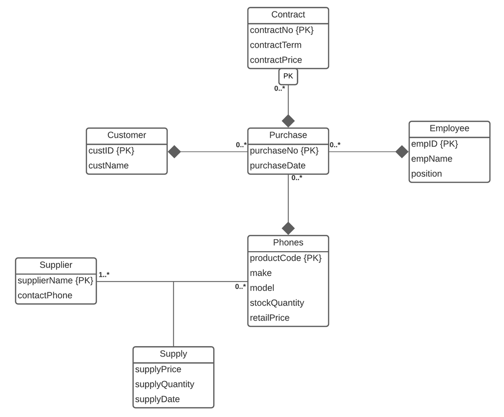

Figure 1: An ER diagram of the business model in UML format.

# ER Model to Relational Database Schema Mapping

The ER diagram is a high-level design of the database. To obtain a low-level design, the diagram is mapped into a relational database schema, where underlined attributes represent primary keys, and attributes with asterisks represent foreign keys.

Supplier(supplierName, contactPhone)  
Supply(supplierName*, productCode*, supplyPrice, supplyQuantity, supplyDate)  
Phones(productCode, make, model, stockQuantity, retailPrice)  
Customer(custID, custName)  
Purchase(purchaseNo, purchaseDate, custID*, productCode*, empID*)  
Contract(contractNo, purchaseNo*, contractTerm, contractPrice)  
Employee(empID, empName, position)

# Creating the Relational Database in Oracle with Dummy Data

Database tables have been created from the relational schema in Oracle SQL Developer with SQL `CREATE TABLE` and `INSERT` statements. Sample data has been created and inserted into these tables to allow for realistic testing later. The method used to create the sample data is briefly described [here](https://github.com/j-b-ferguson/business-database-design-and-test/blob/main/SQL%20code/README.md).

Below is an extract of the relational database SQL script, with a few `INSERT` statements included to show method. The complete script can be viewed [here](https://github.com/j-b-ferguson/business-database-design-and-test/blob/main/SQL%20code/The%20Happy%20Phone%20Company%20Relational%20Database.sql).

```sql
CREATE TABLE Supplier
       (
          suppliername VARCHAR(30),
          contactphone CHAR(12),
          PRIMARY KEY(suppliername)
       );
```

```
##   Table created.
```

```sql
INSERT INTO Supplier
                 (suppliername,
                  contactphone)
     VALUES      ('Hansen and Sons',
                  '428-147-4213' );
```

```
##   1 row created.
```

```sql
INSERT INTO Supplier
                 (suppliername,
                  contactphone)
     VALUES      ('Dicki-Thompson',
                  '871-171-0605');
```

```
##   1 row created.
```

```sql
CREATE TABLE Phones
       (
          productcode   CHAR(11),
          make          VARCHAR(17),
          model         VARCHAR(13),
          stockquantity INT,
          retailprice   INT,
          PRIMARY KEY(productcode)
       );
```

```
##   Table created.
```

```sql
INSERT INTO Phones
                 (productcode,
                  make,
                  model,
                  stockquantity,
                  retailprice)
     VALUES      ('675-971-898',
                  'Apple',
                  'pIJ-91679356G',
                  '1',
                  741);
```

```
##   1 row created.
```

```sql
INSERT INTO Phones
                 (productcode,
                  make,
                  model,
                  stockquantity,
                  retailprice)
     VALUES      ('105-878-560',
                  'Apple',
                  'CRL-52853444Q',
                  '3',
                  937);
```

```
##   1 row created.
```

```sql
CREATE TABLE Customer
       (
          custid   VARCHAR(4),
          custname VARCHAR(25),
          PRIMARY KEY(custid)
       );
```

```
##   Table created.
```

```sql
INSERT INTO Customer
                 (custid,
                  custname)
     VALUES      (1,
                  'Eydie Quixley');
```

```
##   1 row created.
```

```sql
INSERT INTO Customer
                 (custid,
                  custname)
     VALUES      (2,
                  'Isa Arunowicz');
```

```
##   1 row created.
```

```sql
CREATE TABLE Employee
       (
          empid    VARCHAR(2),
          empname  VARCHAR(16),
          position VARCHAR(17),
          PRIMARY KEY(empid)
       );
```

```
##   Table created.
```

```sql
INSERT INTO Employee
                 (empid,
                  empname,
                  position)
     VALUES      (1,
                  'Judith Mumbey',
                  'Director');
```

```
##   1 row created.
```

```sql
INSERT INTO Employee
                 (empid,
                  empname,
                  position)
     VALUES      (2,
                  'Moishe Forsey',
                  'Manager');
```

```
##   1 row created.
```

```sql
CREATE TABLE Purchase
       (
          purchaseno   CHAR(12),
          purchasedate DATE,
          custid       VARCHAR(4),
          productcode  CHAR(11),
          empid        VARCHAR(2),
          PRIMARY KEY(purchaseno),
          FOREIGN KEY(custid) REFERENCES customer(custid),
          FOREIGN KEY(productcode) REFERENCES phones(productcode),
          FOREIGN KEY(empid) REFERENCES employee(empid)
       );
```

```
##   Table created.
```

```sql
INSERT INTO Purchase
                 (purchaseno,
                  purchasedate,
                  custid,
                  productcode,
                  empid)
     VALUES      ('P634-340-525',
                  '20-Sep-2019',
                  425,
                  '334-405-233',
                  4);
```

```
##   1 row created.
```

```sql
INSERT INTO Purchase
                 (purchaseno,
                  purchasedate,
                  custid,
                  productcode,
                  empid)
     VALUES      ('P672-549-119',
                  '01-Mar-2020',
                  258,
                  '852-219-856',
                  5);
```

```
##   1 row created.
```

```sql
CREATE TABLE Supply
       (
          suppliername   VARCHAR(30),
          productcode    CHAR(11),
          supplyprice    INT,
          supplyquantity INT,
          supplydate     DATE,
          PRIMARY KEY(suppliername, productcode),
          FOREIGN KEY(suppliername) REFERENCES supplier(suppliername),
          FOREIGN KEY(productcode) REFERENCES phones(productcode)
       );
```

```
##   Table created.
```

```sql
INSERT INTO Supply
                 (suppliername,
                  productcode,
                  supplyprice,
                  supplyquantity,
                  supplydate)
     VALUES      ('Anderson and Sons',
                  '675-971-898',
                  365,
                  '0',
                  '02-Sep-20');
```

```
##   1 row created.
```

```sql
INSERT INTO Supply
                 (suppliername,
                  productcode,
                  supplyprice,
                  supplyquantity,
                  supplydate)
     VALUES      ('Douglas LLC',
                  '105-878-560',
                  394,
                  '8',
                  '15-Sep-20');
```

```
##   1 row created.
```

```sql
CREATE TABLE Contract
       (
          contractno    CHAR(12),
          purchaseno    CHAR(12),
          contractterm  INT,
          contractprice INT,
          PRIMARY KEY(contractno, purchaseno),
          FOREIGN KEY(purchaseno) REFERENCES purchase(purchaseno)
       );
```

```
##   Table created.
```

```sql
INSERT INTO Contract
                 (contractno,
                  purchaseno,
                  contractterm,
                  contractprice)
     VALUES      ('C908-706-335',
                  'P497-820-348',
                  12,
                  1020);
```

```
##   1 row created.
```

```sql
INSERT INTO contract
                 (contractno,
                  purchaseno,
                  contractterm,
                  contractprice)
     VALUES      ('C039-465-806',
                  'P903-920-423',
                  36,
                  2196);
```

```
##   1 row created.
```

# Testing the Relational Database in Oracle with SQL Queries

A database must be able to handle SQL queries created by an employee based on questions derived from the business rules. Examples include:

- Which employee had the most overall sales?
- Which customer purchased the most products in a given period?
- How many sales were made on a given date?
- How many phone contracts were sold as purchases on a given date?
- What is the most popular selling make and model of phone?
- What is the cost difference between retailPrice and average contractPrice for a given model of phone?
- What is the cost difference between supplyPrice and retailPrice for a given model of phone?
- Which supplier last supplied a particular model of phone?
- How many products were received on a given date?

The following SQL queries demonstrate the good design of the database to handle such questions.

—*Which employee had the most overall sales?*

```sql
SELECT e.empid,
            empname,
            Count(e.empid) AS "SALES COUNT"
     FROM   Employee e
            join Purchase p
              ON e.empid = p.empid
     GROUP  BY e.empid,
               empname
     HAVING Count(e.empid) >= ALL (SELECT Count(e.empid)
                                   FROM   Employee e
                                          join Purchase p
                                            ON e.empid = p.empid
                                   GROUP  BY e.empid);
```

```
##   EMPID EMPNAME          SALES COUNT
     ----- ---------------- -----------
     6     Kleon Dewey              107
```

—*Which customer purchased the most products in November 2020?*

```sql
SELECT c.custid,
            c.custname,
            Count(c.custid) AS "PURCHASES"
     FROM   customer c
            join purchase p
              ON c.custid = p.custid
     WHERE  p.purchasedate BETWEEN '01/NOV/20' AND '30/NOV/20'
     GROUP  BY c.custid,
               c.custname
     HAVING Count(c.custid) >= ALL (SELECT Count(c.custid)
                                    FROM   customer c
                                           join purchase p
                                             ON c.custid = p.custid
                                    WHERE  p.purchasedate BETWEEN
                                           '01/NOV/20' AND '30/NOV/20'
                                    GROUP  BY c.custid);
```

```
##   CUSTID CUSTNAME                   PURCHASES
     ------ ------------------------- ----------
     696    Fanya Attard                       2
```

— *How many sales were made on 07/DEC/20?*

```sql
SELECT SUM(Count(purchaseno)) AS "TOTAL SALES"
     FROM   purchase
     WHERE  purchasedate = '07/DEC/20'
     GROUP  BY purchaseno;
```

```
##   TOTAL SALES
     -----------
               3
```

— *How many phone contracts were sold as purchases on 07/DEC/20?*

```sql
SELECT SUM(Count(contractno)) AS "CONTRACTS SOLD"
     FROM   contract c,
            purchase p
     WHERE  c.purchaseno = p.purchaseno
            AND p.purchasedate = '07/DEC/20'
     GROUP  BY contractno;
```

```
##   CONTRACTS SOLD
     --------------
                  1
```

— *What is the most popular selling make and model of phone?*

```sql
SELECT make,
            model,
            Count(model) AS "SOLD"
     FROM   phones ph
            join purchase pu
              ON pu.productcode = ph.productcode
     GROUP  BY make,
               model
     HAVING Count(model) >= ALL (SELECT Count(model)
                                 FROM   phones ph
                                        join purchase pu
                                          ON pu.productcode = ph.productcode
                                 GROUP  BY make,
                                           model);
```

```
##   MAKE              MODEL               SOLD
     ----------------- ------------- ----------
     Apple             irj-11736694U         25
```

— *What is the cost difference between retailPrice and average contractPrice for the Apple model irj-11736694U?*

```sql
SELECT DISTINCT make,
                     model,
                     contractterm,
                     retailprice,
                     Round(Avg(contractprice))               AS
                     "AVERAGE CONTRACTPRICE",
                     Round(Avg(contractprice)) - retailprice AS "COST DIFFERENCE"
     FROM   phones ph,
            purchase pu,
            contract co
     WHERE  pu.productcode = ph.productcode
            AND pu.purchaseno = co.purchaseno
            AND model = 'irj-11736694U'
     GROUP  BY make,
               model,
               contractterm,
               retailprice
     ORDER  BY contractterm;
```

```
##   MAKE              MODEL         CONTRACTTERM RETAILPRICE AVERAGE CONTRACTPRICE COST DIFFERENCE
     ----------------- ------------- ------------ ----------- --------------------- ---------------
     Apple             irj-11736694U           12        1131                  1196              65
     Apple             irj-11736694U           24        1131                  1752             621
     Apple             irj-11736694U           36        1131                  2079             948
```

— *What is the cost difference between supplyPrice and retailPrice for the Apple model irj-11736694U?*

```sql
SELECT make,
            model,
            retailprice,
            supplyprice,
            ( retailprice - supplyprice ) AS "COST DIFFERENCE"
     FROM   phones p
            join supply s
              ON p.productcode = s.productcode
     WHERE  model = 'irj-11736694U';
```

```
##   MAKE              MODEL         RETAILPRICE SUPPLYPRICE COST DIFFERENCE
     ----------------- ------------- ----------- ----------- ---------------
     Apple             irj-11736694U        1131         314             817
```

— *Which supplier last supplied an Apple model phone?*

```sql
SELECT suppliername,
            make,
            Max(supplydate) AS "SUPPLYDATE"
     FROM   supply s,
            phones p
     WHERE  s.productcode = p.productcode
            AND make = 'Apple'
     GROUP  BY suppliername,
               make
     HAVING Max(supplydate) >= ALL (SELECT Max(supplydate)
                                    FROM   supply s,
                                           phones p
                                    WHERE  s.productcode = p.productcode
                                           AND make = 'Apple');
```

```
##   SUPPLIERNAME                   MAKE  SUPPLYDATE
     ------------------------------ ----- ----------
     Larson Inc                     Apple  13-DEC-20
```

```sql
SELECT supplydate,
            SUM(supplyquantity) AS "PRODUCTS RECEIVED"
     FROM   supply
     WHERE  supplydate = '15/SEP/20'
     GROUP  BY supplydate;
```

```
##   SUPPLYDATE PRODUCTS RECEIVED
     ---------- -----------------
     15-SEP-20                 21
```